# **2020공공데이터공모전**

# **팀명: 비디아 (Busan Data Avengers)**

# **팀원: 정헤지, 양희진**

# **컨설턴트: 주민수**

# **연구 주제: 에너지 생산, 효율도, 수요가격탄력성 및 대체 에너지**

# **1. 파이썬 모듈**

# **Acknowledgement:**

This lab uses datascience Python module developed at UC Berkely.

```python
!pip install datascience
```

```
Downloading jedi-0.19.2-py2.py3-none-any.whl (1.6 MB)
   ━━━━━━━━━━━━━━━━━━━━━━━━━━━━━━━━━━━━━━━━ 1.6/1.6 MB 18.5 MB/s eta 0:00:00
```

```python
import datascience
import numpy as np
import graphviz
import pandas as pd
import matplotlib
%matplotlib inline
import matplotlib.pyplot as plots
import warnings

from datascience import *
from sklearn.feature_extraction.text import CountVectorizer
from sklearn.model_selection import train_test_split
from sklearn.pipeline import Pipeline
from sklearn import tree
from sklearn.tree import DecisionTreeClassifier
from sklearn import metrics
from pandas import *
from numpy import *

import os
os.environ["PATH"] += os.pathsep + 'C:/Program Files (x86)/Graphviz2.38/bin/'
```

# **2. Google Drive mount**

Execute the following code to use csv file downloaded in 2020DataContest folder in Google Drive

```python
from google.colab import drive
drive.mount('/content/drive', force_remount=True)
```

1. !ls를 통해서 Google Drive 안에 있는 csv 파일 확인
2. 각 csv 파일 경로 지정

```python
!ls /content/drive/My\ Drive/2020DataContest/
```

```
'2020공공데이터공모전 (분석).gdoc'   korea_economic_growth_rate.csv
 Cost_Material.csv		     korea_economic_indicator.csv
 Generation_Sales_Type_Year.csv      power_generation_sales_power_loss.csv
```

```python
path1="/content/drive/My Drive/2020DataContest/Generation_Sales_Type_Year.csv"
path2="/content/drive/My Drive/2020DataContest/power_generation_sales_power_loss.csv"
path3="/content/drive/My Drive/2020DataContest/korea_economic_growth_rate.csv"
path4="/content/drive/My Drive/2020DataContest/korea_economic_indicator.csv"
path5="/content/drive/My Drive/2020DataContest/Cost_Material.csv"
Powergentype = Table.read_table(path1)
Powerloss = Table.read_table(path2)
Econgrowthrate = Table.read_table(path3)
Econindicator = Table.read_table(path4)
Materialcost = Table.read_table(path5)
```

# **3. 경제 성장에 따른 에너지 소비율(생산)**

**발전 방식별 에너지 생산량**

- Total -> 상용자가 발전을 제외한 총 발전량
- Total Generation_Business + Purchase -> 총 발전량 + 상용자가 발전중 한전 구입량
- Total Generation_Business + Individual -> 총 발전량 + 상용자가 발전량

```python
Powergentype.show(20)
```

| Year | General_Water Power | Water Lifting_Water Power | Small Hydro_Water Power | Water Power_Total | Anthracite Coal_Steam Power | Soft Coal_Steam Power | Heavy Oil_Steam Power | Gas_Steam Power | Steam Power_Total | General_Combined Cycle Power | Heat Supply_Combined Cycle Power | Combined Cycle Power_Total | Nuclear Power | Renewable Power | Group Power | Internal-Combustion Power | Etc | Total | Individual Power_Purchase | Individual Power_Individual Use | Individual Power_Total | Total Generation_Business + Purchase | Total Generation_Business + Individual |
| --- | --- | --- | --- | --- | --- | --- | --- | --- | --- | --- | --- | --- | --- | --- | --- | --- | --- | --- | --- | --- | --- | --- | --- |
| 2019 | 2.22904e+06 | 3.45838e+06 | 559641 | 6.24706e+06 | 2.59223e+06 | 2.16484e+08 | 1.84248e+06 | 0.012 | 2.20918e+08 | 0 | 0 | 1.10289e+08 | 1.4591e+08 | 3.05263e+07 | 4.60581e+07 | 578912 | 1.36666e+06 | 5.61894e+08 | 1.14641e+06 | 22261140 | 2.34075e+07 | 5.6304e+08 | 5.85301e+08 |
| 2018 | 2.7484e+06 | 3.91104e+06 | 611017 | 7.27045e+06 | 2.67704e+06 | 2.28976e+08 | 5.84525e+06 | 0 | 2.37498e+08 | 0 | 0 | 1.16836e+08 | 1.33505e+08 | 2.71767e+07 | 4.70329e+07 | 528453 | 0 | 5.69848e+08 | 798850 | 22760291 | 2.35591e+07 | 5.70647e+08 | 5.93407e+08 |
| 2017 | 2.2635e+06 | 4.18635e+06 | 545316 | 6.99517e+06 | 4.42661e+06 | 2.2746e+08 | 5.22477e+06 | 220183 | 2.37332e+08 | 9.38391e+07 | 5.77985e+06 | 9.9619e+07 | 1.48427e+08 | 2.41454e+07 | 3.61945e+07 | 513347 | 0 | 5.53226e+08 | 304506 | 22882019 | 2.31865e+07 | 5.40441e+08 | 5.60985e+08 |
| 2016 | 2.15915e+06 | 3.78731e+06 | 687113 | 6.63358e+06 | 7.76068e+06 | 2.01439e+08 | 1.30548e+07 | 368541 | 2.22623e+08 | 9.10641e+07 | 5.85814e+06 | 9.69223e+07 | 1.61995e+08 | 1.89357e+07 | 3.25371e+07 | 573196 | 0 | 5.4022e+08 | 220419 | 20543736 | 2.07642e+07 | 5.40441e+08 | 5.60985e+08 |
| 2015 | 1.5393e+06 | 3.65032e+06 | 606422 | 5.79604e+06 | 7.43827e+06 | 1.99895e+08 | 8.82201e+06 | 222472 | 2.16378e+08 | 9.73751e+07 | 3.22325e+06 | 1.00598e+08 | 1.64762e+08 | 1.73179e+07 | 2.20187e+07 | 643164 | 0 | 5.27515e+08 | 576355 | 17438073 | 1.80144e+07 | 5.28091e+08 | 5.45529e+08 |
| 2014 | 2.13568e+06 | 5.06813e+06 | 615737 | 7.81955e+06 | 8.50606e+06 | 1.95259e+08 | 6.83846e+06 | 568123 | 2.11172e+08 | 1.04301e+08 | 7.40997e+06 | 1.11711e+08 | 1.56407e+08 | 1.46957e+07 | 1.89481e+07 | 655810 | 0 | 5.21409e+08 | 561813 | 18407896 | 1.89697e+07 | 5.21971e+08 | 5.40379e+08 |
| 2013 | 3.79824e+06 | 4.10466e+06 | 491028 | 8.39393e+06 | 8.05449e+06 | 1.93064e+08 | 1.39405e+07 | 3.52589e+06 | 2.18585e+08 | 1.1163e+08 | 1.27705e+07 | 1.244e+08 | 1.38784e+08 | 1.01597e+07 | 1.44032e+07 | 740935 | 0 | 5.15467e+08 | 1.68094e+06 | 20021403 | 2.17023e+07 | 5.17148e+08 | 5.37169e+08 |
| 2012 | 3.44002e+06 | 3.68326e+06 | 529021 | 7.6523e+06 | 8.76776e+06 | 1.90562e+08 | 1.35534e+07 | 3.45287e+06 | 2.16336e+08 | 9.75485e+07 | 1.33335e+07 | 1.10882e+08 | 1.50327e+08 | 8.61787e+06 | 1.29127e+07 | 752070 | 0 | 5.0748e+08 | 2.09412e+06 | 21627537 | 2.37217e+07 | 5.09574e+08 | 5.31202e+08 |
| 2011 | 4.17887e+06 | 3.23298e+06 | 418799 | 7.83065e+06 | 8.50398e+06 | 1.91012e+08 | 9.45634e+06 | 2.23262e+06 | 2.11205e+08 | 9.0453e+07 | 1.10264e+07 | 1.01479e+08 | 1.54723e+08 | 7.59239e+06 | 1.24291e+07 | 820533 | 0 | 4.9608e+08 | 813434 | 21274450 | 2.20879e+07 | 4.96893e+08 | 5.18168e+08 |
| 2010 | 3.33956e+06 | 2.78993e+06 | 342409 | 6.4719e+06 | 8.35987e+06 | 1.89927e+08 | 1.08744e+07 | 2.28754e+06 | 2.11449e+08 | 8.15638e+07 | 1.24483e+07 | 9.40121e+07 | 1.48596e+08 | 4.47806e+06 | 8.08023e+06 | 730695 | 0 | 4.73818e+08 | 842196 | 20368158 | 2.12104e+07 | 4.7466e+08 | 4.95028e+08 |
| 2009 | 2.5961e+06 | 2.82799e+06 | 217071 | 5.64116e+06 | 7.97766e+06 | 1.85826e+08 | 1.19701e+07 | 761682 | 2.06535e+08 | 5.51081e+07 | 9.37788e+06 | 6.4486e+07 | 1.47771e+08 | 1.79061e+06 | 5.827e+06 | 696953 | 0 | 4.32748e+08 | 856135 | 18843716 | 1.96999e+07 | 4.33604e+08 | 4.52447e+08 |
| 2008 | 2.85213e+06 | 2.49254e+06 | 217984 | 5.56265e+06 | 6.92899e+06 | 1.67227e+08 | 7.98156e+06 | 1.51776e+06 | 1.83655e+08 | 6.3812e+07 | 1.07074e+07 | 7.45194e+07 | 1.50958e+08 | 1.37342e+06 | 5.05442e+06 | 502708 | 0 | 4.21626e+08 | 729277 | 20255832 | 2.09851e+07 | 4.22355e+08 | 4.42611e+08 |
| 2007 | 3.47527e+06 | 1.41081e+06 | 156381 | 5.04246e+06 | 6.06154e+06 | 1.49623e+08 | 1.57027e+07 | 2.0277e+06 | 1.73415e+08 | 6.58369e+07 | 1.05685e+07 | 7.64054e+07 | 1.42937e+08 | 830824 | 3.08514e+06 | 578356 | 0 | 4.02294e+08 | 830063 | 22282788 | 2.31129e+07 | 4.03125e+08 | 4.25407e+08 |
| 2006 | 3.32628e+06 | 1.75108e+06 | 141256 | 5.21862e+06 | 5.70939e+06 | 1.34637e+08 | 1.43068e+07 | 1.25816e+06 | 1.55911e+08 | 5.73621e+07 | 9.77625e+06 | 6.71383e+07 | 1.48749e+08 | 511223 | 2.59673e+06 | 677296 | 0 | 3.80802e+08 | 378693 | 21808234 | 2.21869e+07 | 3.81181e+08 | 4.02989e+08 |
| 2005 | 3.53557e+06 | 1.51559e+06 | 137729 | 5.18889e+06 | 5.78978e+06 | 1.29102e+08 | 1.55291e+07 | 786366 | 1.51207e+08 | 4.78407e+07 | 9.61621e+06 | 5.74569e+07 | 1.46779e+08 | 404101 | 2.75854e+06 | 575339 | 0 | 3.6437e+08 | 269341 | 24840181 | 2.51095e+07 | 3.64639e+08 | 3.8948e+08 |
| 2004 | 4.19835e+06 | 1.55035e+06 | 112732 | 5.86143e+06 | 5.78707e+06 | 1.2276e+08 | 1.6084e+07 | 733318 | 1.45365e+08 | 4.5425e+07 | 1.0027e+07 | 5.54519e+07 | 1.30715e+08 | 350183 | 3.55254e+06 | 406895 | 0 | 3.41703e+08 | 445453 | 25885585 | 2.6331e+07 | 3.42148e+08 | 3.68034e+08 |
| 2003 | 4.75694e+06 | 2.00141e+06 | 128636 | 6.88698e+06 | 6.95994e+06 | 1.14971e+08 | 1.66639e+07 | 1.67418e+06 | 1.40269e+08 | 3.05223e+07 | 9.85234e+06 | 4.03746e+07 | 1.29672e+08 | 0 | 0 | 370125 | 0 | 3.17573e+08 | 4.87871e+06 | 25304512 | 3.01832e+07 | 3.22452e+08 | 3.47756e+08 |
| 2002 | 3.13667e+06 | 2.07827e+06 | 96103.3 | 5.31105e+06 | 6.67454e+06 | 1.12991e+08 | 1.74931e+07 | 1.77121e+06 | 1.38929e+08 | 2.86237e+07 | 9.71327e+06 | 3.8337e+07 | 1.19103e+08 | 0 | 0 | 353023 | 0 | 3.02033e+08 | 4.44066e+06 | 25546883 | 2.99875e+07 | 3.06474e+08 | 3.32021e+08 |
| 2001 | 2.25758e+06 | 1.82081e+06 | 72354.1 | 4.15075e+06 | 7.00738e+06 | 1.0525e+08 | 2.16223e+07 | 1.55693e+06 | 1.35437e+08 | 2.02858e+07 | 8.74719e+06 | 2.9033e+07 | 1.12133e+08 | 0 | 0 | 324939 | 0 | 2.81078e+08 | 4.14532e+06 | 24662195 | 2.88075e+07 | 2.85224e+08 | 3.09886e+08 |
| 2000 | 3.94102e+06 | 1.60027e+06 | 68535.6 | 5.60982e+06 | 7.02975e+06 | 9.23977e+07 | 1.88882e+07 | 1.63189e+06 | 1.19948e+08 | 1.72997e+07 | 9.56349e+06 | 2.68631e+07 | 1.08964e+08 | 0 | 0 | 293861 | 0 | 2.61678e+08 | 4.72141e+06 | 24043440 | 2.87649e+07 | 2.664e+08 | 2.90443e+08 |

... (39 rows omitted)

**에너지 손실**

```python
Powerloss.show(20)
```

| Year | Transmission Unit Power Initial Volume(A) | Transmission Volume(B) | Transmission Loss Volume(A-B) | Transmission Loss Rate(%) | Sales Volume(C) | Distribution Loss Volume(B-C) | Distribution Loss Rate(%) | Total Loss Volume(A-C) | Total Loss Rate(%) |
| --- | --- | --- | --- | --- | --- | --- | --- | --- | --- |
| 2019 | 5.36198e+08 | 5.27752e+08 | 8.44556e+06 | 1.575 | 5.17197e+08 | 1.05549e+07 | 2 | 1.90005e+07 | 3.544 |
| 2018 | 5.43232e+08 | 5.34612e+08 | 8.61937e+06 | 1.58668 | 5.23872e+08 | 1.074e+07 | 2.00893 | 1.93594e+07 | 3.56374 |
| 2017 | 5.25711e+08 | 5.17358e+08 | 8.35273e+06 | 1.59 | 5.06921e+08 | 1.04374e+07 | 2.02 | 1.87901e+07 | 3.57 |
| 2016 | 5.14119e+08 | 5.05937e+08 | 8.18161e+06 | 1.59 | 4.95644e+08 | 1.02932e+07 | 2.03 | 1.84748e+07 | 3.59 |
| 2015 | 4.99239e+08 | 4.91286e+08 | 7.95384e+06 | 1.59319 | 4.8126e+08 | 1.00254e+07 | 2.04064 | 1.79792e+07 | 3.60132 |
| 2014 | 4.94717e+08 | 4.86875e+08 | 7.84176e+06 | 1.5851 | 4.76446e+08 | 1.04287e+07 | 2.14196 | 1.82704e+07 | 3.69311 |
| 2013 | 4.91003e+08 | 4.83172e+08 | 7.83068e+06 | 1.59483 | 4.72692e+08 | 1.04804e+07 | 2.16909 | 1.83111e+07 | 3.72933 |
| 2012 | 4.84334e+08 | 4.76693e+08 | 7.6409e+06 | 1.41817 | 4.67043e+08 | 9.65061e+06 | 2.02449 | 1.72915e+07 | 3.57016 |
| 2011 | 4.7265e+08 | 4.6544e+08 | 7.2099e+06 | 1.525 | 4.5522e+08 | 1.02205e+07 | 2.196 | 1.74304e+07 | 3.688 |
| 2010 | 4.51433e+08 | 4.44144e+08 | 7.28894e+06 | 1.615 | 4.33399e+08 | 1.07453e+07 | 2.419 | 1.80342e+07 | 3.995 |
| 2009 | 4.11631e+08 | 4.04758e+08 | 6.87318e+06 | 1.67 | 3.94861e+08 | 9.89656e+06 | 2.445 | 1.67697e+07 | 4.074 |
| 2008 | 4.01726e+08 | 3.94247e+08 | 7.47941e+06 | 1.862 | 3.8562e+08 | 8.62697e+06 | 2.188 | 1.61064e+07 | 4.009 |
| 2007 | 3.84693e+08 | 3.7801e+08 | 6.68335e+06 | 1.737 | 3.69348e+08 | 8.66181e+06 | 2.291 | 1.53452e+07 | 3.989 |
| 2006 | 3.63054e+08 | 3.5626e+08 | 6.79372e+06 | 1.871 | 3.48467e+08 | 7.79351e+06 | 2.188 | 1.45872e+07 | 4.018 |
| 2005 | 3.46207e+08 | 3.36549e+08 | 9.65841e+06 | 2.79 | 3.30593e+08 | 5.95636e+06 | 1.77 | 1.56148e+07 | 4.51 |
| 2004 | 3.24885e+08 | 3.16019e+08 | 8.86582e+06 | 2.729 | 3.10395e+08 | 5.62462e+06 | 1.78 | 1.44904e+07 | 4.46 |
| 2003 | 3.05645e+08 | 2.97327e+08 | 8.31818e+06 | 2.722 | 2.92105e+08 | 5.22105e+06 | 1.756 | 1.35392e+07 | 4.43 |
| 2002 | 2.90058e+08 | 2.8215e+08 | 7.90846e+06 | 2.727 | 2.77064e+08 | 5.08602e+06 | 1.803 | 1.29945e+07 | 4.48 |
| 2001 | 2.69842e+08 | 2.62296e+08 | 7.54587e+06 | 2.796 | 2.57702e+08 | 4.59456e+06 | 1.752 | 1.21404e+07 | 4.499 |
| 2000 | 2.51953e+08 | 2.4446e+08 | 7.49296e+06 | 2.974 | 2.40082e+08 | 4.37823e+06 | 1.791 | 1.18712e+07 | 4.712 |

... (39 rows omitted)

**경제 성장률**

```python
Econgrowthrate.show(20)
```

| Year | Economic Growth Rate(%) | GDP(10 Hundred Million Won) | Gross National Income(10 Hundred Million Won) | National Income Per Head(US$) | Total Savings Rate(%) | Gross Domestic Investment Rate(%) |
| --- | --- | --- | --- | --- | --- | --- |
| 2019 | 2 | 1.91904e+06 | 1.93572e+06 | 32114.9 | 34.7 | 31.2 |
| 2018 | 2.7 | 1.78227e+06 | 1.78109e+06 | 31349 | 34.8 | 30.4 |
| 2017 | 3.1 | 1.7304e+06 | 1.73046e+06 | 29745 | 36.3 | 31.2 |
| 2016 | 2.8 | 1.64179e+06 | 1.64621e+06 | 27560.9 | 36.1 | 29.3 |
| 2015 | 2.8 | 1.56412e+06 | 1.56838e+06 | 27170.9 | 35.6 | 28.9 |
| 2014 | 3.3 | 1.48608e+06 | 1.49076e+06 | 27892.2 | 34.5 | 29.3 |
| 2013 | 2.9 | 1.42946e+06 | 1.43964e+06 | 26079.3 | 34.3 | 29 |
| 2012 | 2.3 | 1.37746e+06 | 1.3916e+06 | 24599.9 | 34.2 | 30.8 |
| 2011 | 3.7 | 1.33268e+06 | 1.34053e+06 | 24225.6 | 34.6 | 32.9 |
| 2010 | 6.5 | 1.26531e+06 | 1.26658e+06 | 22105.3 | 35 | 32.1 |
| 2009 | 0.7 | 1.15171e+06 | 1.14898e+06 | 18256.2 | 32.9 | 28.6 |
| 2008 | 2.8 | 1.10449e+06 | 1.10441e+06 | 20419.1 | 32.9 | 33 |
| 2007 | 5.5 | 1.04326e+06 | 1.04009e+06 | 22992.1 | 33.2 | 32.8 |
| 2006 | 5.2 | 966055 | 962447 | 20794.7 | 32.9 | 33 |
| 2005 | 3.9 | 919797 | 912609 | 18490.4 | 33.8 | 32.5 |
| 2004 | 4.9 | 876033 | 874239 | 15884.1 | 35.5 | 32.3 |
| 2003 | 2.9 | 810915 | 807778 | 14151.1 | 33.3 | 32.3 |
| 2002 | 7.4 | 761939 | 758863 | 12729.4 | 31.8 | 31.2 |
| 2001 | 4.5 | 688165 | 683447 | 11177.1 | 32.4 | 31.9 |
| 2000 | 8.798 | 635185 | 630614 | 11865.3 | 34.4 | 33.2 |

... (8 rows omitted)

**데이터 관리**

a) Econgrowthrate 데이터에서 Year 과 GDP 만 뽑아 새로운 변수 Econgrowthrate_rate에 저장

b) Powergentype 데이터에 GDP 데이터를 추가해 새로운 변수 Powergentype_econgrowth에 저장

c) join 함수 사용시 오름차순으로 배열 되므로 기존의 내림차순 배열에 따라 sort 함수 사용

```python
Econgrowthrate_rate = Econgrowthrate.select("Year", "GDP(10 Hundred Million Won)")
Econgrowthrate_rate.show(25)
```

| Year | GDP(10 Hundred Million Won) |
| --- | --- |
| 2019 | 1.91904e+06 |
| 2018 | 1.78227e+06 |
| 2017 | 1.7304e+06 |
| 2016 | 1.64179e+06 |
| 2015 | 1.56412e+06 |
| 2014 | 1.48608e+06 |
| 2013 | 1.42946e+06 |
| 2012 | 1.37746e+06 |
| 2011 | 1.33268e+06 |
| 2010 | 1.26531e+06 |
| 2009 | 1.15171e+06 |
| 2008 | 1.10449e+06 |
| 2007 | 1.04326e+06 |
| 2006 | 966055 |
| 2005 | 919797 |
| 2004 | 876033 |
| 2003 | 810915 |
| 2002 | 761939 |
| 2001 | 688165 |
| 2000 | 635185 |
| 1999 | 576873 |
| 1998 | 524477 |
| 1997 | 530347 |
| 1996 | 481141 |
| 1995 | 428927 |

... (3 rows omitted)

```python
Powergentype_econgrowth = Econgrowthrate_rate.join("Year", Powergentype, "Year")
Powergentype_econgrowth_sort = Powergentype_econgrowth.sort("Year", descending=True)
Powergentype_econgrowth_sort.show(25)
```

| Year | GDP(10 Hundred Million Won) | General_Water Power | Water Lifting_Water Power | Small Hydro_Water Power | Water Power_Total | Anthracite Coal_Steam Power | Soft Coal_Steam Power | Heavy Oil_Steam Power | Gas_Steam Power | Steam Power_Total | General_Combined Cycle Power | Heat Supply_Combined Cycle Power | Combined Cycle Power_Total | Nuclear Power | Renewable Power | Group Power | Internal-Combustion Power | Etc | Total | Individual Power_Purchase | Individual Power_Individual Use | Individual Power_Total | Total Generation_Business + Purchase | Total Generation_Business + Individual |
| --- | --- | --- | --- | --- | --- | --- | --- | --- | --- | --- | --- | --- | --- | --- | --- | --- | --- | --- | --- | --- | --- | --- | --- | --- |
| 2019 | 1.91904e+06 | 2.22904e+06 | 3.45838e+06 | 559641 | 6.24706e+06 | 2.59223e+06 | 2.16484e+08 | 1.84248e+06 | 0.012 | 2.20918e+08 | 0 | 0 | 1.10289e+08 | 1.4591e+08 | 3.05263e+07 | 4.60581e+07 | 578912 | 1.36666e+06 | 5.61894e+08 | 1.14641e+06 | 22261140 | 2.34075e+07 | 5.6304e+08 | 5.85301e+08 |
| 2018 | 1.78227e+06 | 2.7484e+06 | 3.91104e+06 | 611017 | 7.27045e+06 | 2.67704e+06 | 2.28976e+08 | 5.84525e+06 | 0 | 2.37498e+08 | 0 | 0 | 1.16836e+08 | 1.33505e+08 | 2.71767e+07 | 4.70329e+07 | 528453 | 0 | 5.69848e+08 | 798850 | 22760291 | 2.35591e+07 | 5.70647e+08 | 5.93407e+08 |
| 2017 | 1.7304e+06 | 2.2635e+06 | 4.18635e+06 | 545316 | 6.99517e+06 | 4.42661e+06 | 2.2746e+08 | 5.22477e+06 | 220183 | 2.37332e+08 | 9.38391e+07 | 5.77985e+06 | 9.9619e+07 | 1.48427e+08 | 2.41454e+07 | 3.61945e+07 | 513347 | 0 | 5.53226e+08 | 304506 | 22882019 | 2.31865e+07 | 5.40441e+08 | 5.60985e+08 |
| 2016 | 1.64179e+06 | 2.15915e+06 | 3.78731e+06 | 687113 | 6.63358e+06 | 7.76068e+06 | 2.01439e+08 | 1.30548e+07 | 368541 | 2.22623e+08 | 9.10641e+07 | 5.85814e+06 | 9.69223e+07 | 1.61995e+08 | 1.89357e+07 | 3.25371e+07 | 573196 | 0 | 5.4022e+08 | 220419 | 20543736 | 2.07642e+07 | 5.40441e+08 | 5.60985e+08 |
| 2015 | 1.56412e+06 | 1.5393e+06 | 3.65032e+06 | 606422 | 5.79604e+06 | 7.43827e+06 | 1.99895e+08 | 8.82201e+06 | 222472 | 2.16378e+08 | 9.73751e+07 | 3.22325e+06 | 1.00598e+08 | 1.64762e+08 | 1.73179e+07 | 2.20187e+07 | 643164 | 0 | 5.27515e+08 | 576355 | 17438073 | 1.80144e+07 | 5.28091e+08 | 5.45529e+08 |
| 2014 | 1.48608e+06 | 2.13568e+06 | 5.06813e+06 | 615737 | 7.81955e+06 | 8.50606e+06 | 1.95259e+08 | 6.83846e+06 | 568123 | 2.11172e+08 | 1.04301e+08 | 7.40997e+06 | 1.11711e+08 | 1.56407e+08 | 1.46957e+07 | 1.89481e+07 | 655810 | 0 | 5.21409e+08 | 561813 | 18407896 | 1.89697e+07 | 5.21971e+08 | 5.40379e+08 |
| 2013 | 1.42946e+06 | 3.79824e+06 | 4.10466e+06 | 491028 | 8.39393e+06 | 8.05449e+06 | 1.93064e+08 | 1.39405e+07 | 3.52589e+06 | 2.18585e+08 | 1.1163e+08 | 1.27705e+07 | 1.244e+08 | 1.38784e+08 | 1.01597e+07 | 1.44032e+07 | 740935 | 0 | 5.15467e+08 | 1.68094e+06 | 20021403 | 2.17023e+07 | 5.17148e+08 | 5.37169e+08 |
| 2012 | 1.37746e+06 | 3.44002e+06 | 3.68326e+06 | 529021 | 7.6523e+06 | 8.76776e+06 | 1.90562e+08 | 1.35534e+07 | 3.45287e+06 | 2.16336e+08 | 9.75485e+07 | 1.33335e+07 | 1.10882e+08 | 1.50327e+08 | 8.61787e+06 | 1.29127e+07 | 752070 | 0 | 5.0748e+08 | 2.09412e+06 | 21627537 | 2.37217e+07 | 5.09574e+08 | 5.31202e+08 |
| 2011 | 1.33268e+06 | 4.17887e+06 | 3.23298e+06 | 418799 | 7.83065e+06 | 8.50398e+06 | 1.91012e+08 | 9.45634e+06 | 2.23262e+06 | 2.11205e+08 | 9.0453e+07 | 1.10264e+07 | 1.01479e+08 | 1.54723e+08 | 7.59239e+06 | 1.24291e+07 | 820533 | 0 | 4.9608e+08 | 813434 | 21274450 | 2.20879e+07 | 4.96893e+08 | 5.18168e+08 |
| 2010 | 1.26531e+06 | 3.33956e+06 | 2.78993e+06 | 342409 | 6.4719e+06 | 8.35987e+06 | 1.89927e+08 | 1.08744e+07 | 2.28754e+06 | 2.11449e+08 | 8.15638e+07 | 1.24483e+07 | 9.40121e+07 | 1.48596e+08 | 4.47806e+06 | 8.08023e+06 | 730695 | 0 | 4.73818e+08 | 842196 | 20368158 | 2.12104e+07 | 4.7466e+08 | 4.95028e+08 |
| 2009 | 1.15171e+06 | 2.5961e+06 | 2.82799e+06 | 217071 | 5.64116e+06 | 7.97766e+06 | 1.85826e+08 | 1.19701e+07 | 761682 | 2.06535e+08 | 5.51081e+07 | 9.37788e+06 | 6.4486e+07 | 1.47771e+08 | 1.79061e+06 | 5.827e+06 | 696953 | 0 | 4.32748e+08 | 856135 | 18843716 | 1.96999e+07 | 4.33604e+08 | 4.52447e+08 |
| 2008 | 1.10449e+06 | 2.85213e+06 | 2.49254e+06 | 217984 | 5.56265e+06 | 6.92899e+06 | 1.67227e+08 | 7.98156e+06 | 1.51776e+06 | 1.83655e+08 | 6.3812e+07 | 1.07074e+07 | 7.45194e+07 | 1.50958e+08 | 1.37342e+06 | 5.05442e+06 | 502708 | 0 | 4.21626e+08 | 729277 | 20255832 | 2.09851e+07 | 4.22355e+08 | 4.42611e+08 |
| 2007 | 1.04326e+06 | 3.47527e+06 | 1.41081e+06 | 156381 | 5.04246e+06 | 6.06154e+06 | 1.49623e+08 | 1.57027e+07 | 2.0277e+06 | 1.73415e+08 | 6.58369e+07 | 1.05685e+07 | 7.64054e+07 | 1.42937e+08 | 830824 | 3.08514e+06 | 578356 | 0 | 4.02294e+08 | 830063 | 22282788 | 2.31129e+07 | 4.03125e+08 | 4.25407e+08 |
| 2006 | 966055 | 3.32628e+06 | 1.75108e+06 | 141256 | 5.21862e+06 | 5.70939e+06 | 1.34637e+08 | 1.43068e+07 | 1.25816e+06 | 1.55911e+08 | 5.73621e+07 | 9.77625e+06 | 6.71383e+07 | 1.48749e+08 | 511223 | 2.59673e+06 | 677296 | 0 | 3.80802e+08 | 378693 | 21808234 | 2.21869e+07 | 3.81181e+08 | 4.02989e+08 |
| 2005 | 919797 | 3.53557e+06 | 1.51559e+06 | 137729 | 5.18889e+06 | 5.78978e+06 | 1.29102e+08 | 1.55291e+07 | 786366 | 1.51207e+08 | 4.78407e+07 | 9.61621e+06 | 5.74569e+07 | 1.46779e+08 | 404101 | 2.75854e+06 | 575339 | 0 | 3.6437e+08 | 269341 | 24840181 | 2.51095e+07 | 3.64639e+08 | 3.8948e+08 |
| 2004 | 876033 | 4.19835e+06 | 1.55035e+06 | 112732 | 5.86143e+06 | 5.78707e+06 | 1.2276e+08 | 1.6084e+07 | 733318 | 1.45365e+08 | 4.5425e+07 | 1.0027e+07 | 5.54519e+07 | 1.30715e+08 | 350183 | 3.55254e+06 | 406895 | 0 | 3.41703e+08 | 445453 | 25885585 | 2.6331e+07 | 3.42148e+08 | 3.68034e+08 |
| 2003 | 810915 | 4.75694e+06 | 2.00141e+06 | 128636 | 6.88698e+06 | 6.95994e+06 | 1.14971e+08 | 1.66639e+07 | 1.67418e+06 | 1.40269e+08 | 3.05223e+07 | 9.85234e+06 | 4.03746e+07 | 1.29672e+08 | 0 | 0 | 370125 | 0 | 3.17573e+08 | 4.87871e+06 | 25304512 | 3.01832e+07 | 3.22452e+08 | 3.47756e+08 |
| 2002 | 761939 | 3.13667e+06 | 2.07827e+06 | 96103.3 | 5.31105e+06 | 6.67454e+06 | 1.12991e+08 | 1.74931e+07 | 1.77121e+06 | 1.38929e+08 | 2.86237e+07 | 9.71327e+06 | 3.8337e+07 | 1.19103e+08 | 0 | 0 | 353023 | 0 | 3.02033e+08 | 4.44066e+06 | 25546883 | 2.99875e+07 | 3.06474e+08 | 3.32021e+08 |
| 2001 | 688165 | 2.25758e+06 | 1.82081e+06 | 72354.1 | 4.15075e+06 | 7.00738e+06 | 1.0525e+08 | 2.16223e+07 | 1.55693e+06 | 1.35437e+08 | 2.02858e+07 | 8.74719e+06 | 2.9033e+07 | 1.12133e+08 | 0 | 0 | 324939 | 0 | 2.81078e+08 | 4.14532e+06 | 24662195 | 2.88075e+07 | 2.85224e+08 | 3.09886e+08 |
| 2000 | 635185 | 3.94102e+06 | 1.60027e+06 | 68535.6 | 5.60982e+06 | 7.02975e+06 | 9.23977e+07 | 1.88882e+07 | 1.63189e+06 | 1.19948e+08 | 1.72997e+07 | 9.56349e+06 | 2.68631e+07 | 1.08964e+08 | 0 | 0 | 293861 | 0 | 2.61678e+08 | 4.72141e+06 | 24043440 | 2.87649e+07 | 2.664e+08 | 2.90443e+08 |
| 1999 | 576873 | 4.06866e+06 | 1.90697e+06 | 90600 | 6.06623e+06 | 6.69747e+06 | 7.69063e+07 | 1.1524e+07 | 1.34483e+06 | 9.64725e+07 | 1.87656e+07 | 9.90948e+06 | 2.8675e+07 | 1.03064e+08 | 0 | 0 | 381697 | 0 | 2.34659e+08 | 4.66543e+06 | 22827413 | 2.74928e+07 | 2.39325e+08 | 2.62152e+08 |
| 1998 | 524477 | 4.18659e+06 | 1.81962e+06 | 92826 | 6.09904e+06 | 6.51017e+06 | 7.11522e+07 | 9.94263e+06 | 1.43662e+06 | 8.90416e+07 | 1.76512e+07 | 8.85381e+06 | 2.6505e+07 | 8.9689e+07 | 0 | 0 | 575291 | 0 | 2.1191e+08 | 3.3905e+06 | 21896987 | 2.52875e+07 | 2.153e+08 | 2.37197e+08 |
| 1997 | 530347 | 2.73716e+06 | 2.58953e+06 | 76831 | 5.40352e+06 | 6.0484e+06 | 6.36802e+07 | 2.74081e+07 | 7.66122e+06 | 1.04798e+08 | 2.35916e+07 | 1.08325e+07 | 3.44241e+07 | 7.70856e+07 | 0 | 0 | 718025 | 0 | 2.22379e+08 | 2.06535e+06 | 22142872 | 2.42082e+07 | 2.24445e+08 | 2.46587e+08 |
| 1996 | 481141 | 2.35369e+06 | 2.77697e+06 | 70669 | 5.20132e+06 | 6.94879e+06 | 5.27011e+07 | 2.90672e+07 | 8.22914e+06 | 9.69462e+07 | 1.5795e+07 | 1.11475e+07 | 2.69425e+07 | 7.39243e+07 | 0 | 0 | 771846 | 0 | 2.03786e+08 | 1.70734e+06 | 20352165 | 2.20595e+07 | 2.05494e+08 | 2.25846e+08 |
| 1995 | 428927 | 2.68934e+06 | 2.718e+06 | 70587 | 5.47792e+06 | 6.51068e+06 | 4.50548e+07 | 2.87392e+07 | 8.9485e+06 | 8.92531e+07 | 1.17212e+07 | 8.80013e+06 | 2.05213e+07 | 6.70286e+07 | 0 | 0 | 824819 | 0 | 1.83106e+08 | 1.555e+06 | 18885640 | 2.04406e+07 | 1.84661e+08 | 2.03546e+08 |

... (3 rows omitted)

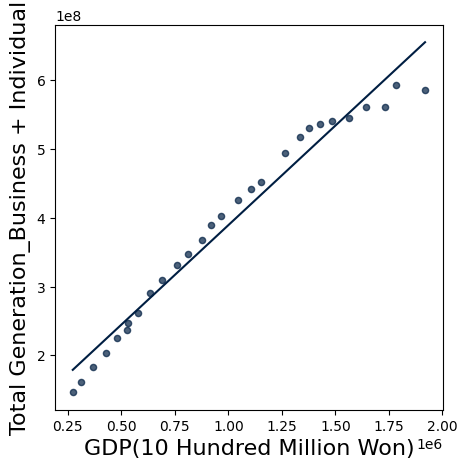

```python
Powergentype_econgrowth_sort.scatter('GDP(10 Hundred Million Won)', 'Total Generation_Business + Individual', fit_line=True)
```

-> 위 그래프를 통해 2000년도 부터 2014년까지는 GDP의 증가율보다 에너지 생산량의 증가율이 더 크다는 것을 알 수 있다. 2015년 송변전 과정에서 발생하는 손실률을 줄이기 위해 한전에서 교류에서 직류로의 변환, 발전소와 송변전 시설 간의 위치 최소화, 민간과의 협력을 등을 통해 노력한 결과 GDP 증가율 보다 에너지 생산량의 증가율이 낮아 질 수 있었다. 에너지 생산은 그 수요에 따라 결정 된다. 수요는 또한 해당 년도의 날씨, 경기 등 많은 요인들의 영향을 받는다. 하지만 송변전을 줄이기 위한 노력도 2015년 이후 많은 변화를 야기 했다는 것을 해당 그래프가 뒷받침 해준다.

# **4. 에너지 효율도**

- 우리나라는 석탄, 원자력, 가스, 신재생, 유류, 양수 순으로 발전 의존도가 분포 되고 있음.

**원자력, 유연탄, 무연탄, 유류, 가스의 발전단가**

```python
Materialcost.show(20)
```

| Year | Nuclear | Soft Coal | Anthracite | Oil | Gas |
| --- | --- | --- | --- | --- | --- |
| 2020 | 5.96 | 51.623 | 69.276 | 187.277 | 84.68 |
| 2019 | 5.862 | 59.492 | 60.578 | 194.603 | 113.936 |
| 2018 | 5.86177 | 54.0952 | 63.7607 | 159.162 | 88.9666 |
| 2017 | 5.74 | 48.32 | 66.54 | 142.31 | 84.17 |
| 2016 | 5.38 | 35.505 | 56.895 | 131.245 | 94.886 |
| 2015 | 5.01227 | 39.6407 | 53.4686 | 204.216 | 146.244 |
| 2014 | 4.68882 | 36.6103 | 58.9822 | 217.749 | 141.591 |
| 2013 | 4.49185 | 39.2736 | 60.4888 | 238.093 | 139.485 |
| 2012 | 3.693 | 50.184 | 79.383 | 225.18 | 137.456 |
| 2011 | 3.726 | 47.68 | 73.08 | 201.596 | 117.551 |
| 2010 | 3.27 | 38.976 | 72.566 | 159.84 | 106.554 |
| 2009 | 3.1362 | 54.1714 | 90.5804 | 134.844 | 179.22 |
| 2008 | 3.08 | 24.57 | 63.22 | 126.23 | 91.96 |
| 2007 | 3.11 | 18.9 | 56.74 | 86.07 | 87.55 |
| 2006 | 3.18 | 21.72 | 60.14 | 92.68 | 83.86 |
| 2005 | 3.22 | 21.83 | 51.11 | 72.96 | 71.77 |
| 2004 | 3.268 | 13.968 | 47.102 | 62.512 | 57.462 |
| 2003 | 3.437 | 12.826 | 51.311 | 68.923 | 57.94 |
| 2002 | 3.602 | 14.984 | 45.621 | 54.763 | 63.152 |
| 2001 | 3.611 | 14.679 | 48.285 | 56.674 | 60.756 |

- 신재생 에너지나 양수의 경우 환경 보호에 있어 유리하게 작용하기 때문에 그 가치를 환산하기에는 힘들다. 따라서 원자력, 유연탄, 무연탄, 유류, 가스에 국한되어 발전 의존도를 기준으로 석탄, 원자력, 가스, 유류 순으로 의존도를 퍼센트로 표현. 한국전력공사 연도별 한국 전력 통계에 따르면 2019년 기준 원자력 25.9%, 석탄 40.4%, 가스 25.6%, 신재생 6.5%, 유류 0.6%, 양수 0.6%. 우리는 신재생 에너지와 양수를 제외한 원자력, 석탄, 가스, 유류만 비교해야한다. 하지만 한국전력공사의 데이터에서는 무연탄과 유연탄을 합쳐 석탄으로 구별하여 제공해주고 있기 때문에 lamda 함수를 통해 (무연탄 단가 + 유연탄 단가)/2를 해 석탄의 단가로 지정한다. (25.9/(25.9+40.4+25.6+0.6) * 100) = 28%, 석탄 (40.4/(25.9+40.4+25.6+0.6) * 100) = 43.68%, 가스 (25.6/(25.9+40.4+25.6+0.6) * 100) = 27.68%, 유류 (0.6/(25.9+40.4+25.6+0.6) * 100) = 0.65%로 환산.
- 단가가 싸고 의존도 높을 경우 단가 대비 생산성이 좋다고 판단할 수 있다. 생산성의 좋은 정도를 수로 표현하기 위해서는 단가가 싸지고 의존도가 높아질때 수가 커지기 위해서 반비례 식을 만들어야 하고 이에 따라 lambda 함수를 이용하여 의존도/단가로 생산 효율도를 구하여 기존 Materialcost의 기존 데이터에 새로운 데이터를 추가 해준다.

```python
Coal_total = Materialcost.apply(lambda x, y: (x+y)/2, "Soft Coal", "Anthracite")
Re_Materialcost = Materialcost.with_column("Coal", Coal_total)
Nuclear_eff = Re_Materialcost.apply(lambda x: 28/x, "Nuclear")
Coal_eff = Re_Materialcost.apply(lambda y: 43.68/y, "Coal")
Oil_eff = Re_Materialcost.apply(lambda z: 0.65/z, "Oil")
Gas_eff = Re_Materialcost.apply(lambda i: 27.68/i, "Gas")
Extended_Materialcost = Re_Materialcost.with_column("Nuclear_eff", Nuclear_eff)
Extended_Materialcost = Extended_Materialcost.with_column("Coal_eff", Coal_eff)
Extended_Materialcost = Extended_Materialcost.with_column("Oil_eff", Oil_eff)
Extended_Materialcost = Extended_Materialcost.with_column("Gas_eff", Gas_eff)
Extended_Materialcost.show(20)
```

| Year | Nuclear | Soft Coal | Anthracite | Oil | Gas | Coal | Nuclear_eff | Coal_eff | Oil_eff | Gas_eff |
| --- | --- | --- | --- | --- | --- | --- | --- | --- | --- | --- |
| 2020 | 5.96 | 51.623 | 69.276 | 187.277 | 84.68 | 60.4495 | 4.69799 | 0.722587 | 0.00347079 | 0.326878 |
| 2019 | 5.862 | 59.492 | 60.578 | 194.603 | 113.936 | 60.035 | 4.77653 | 0.727576 | 0.00334013 | 0.242943 |
| 2018 | 5.86177 | 54.0952 | 63.7607 | 159.162 | 88.9666 | 58.928 | 4.77671 | 0.741244 | 0.0040839 | 0.311128 |
| 2017 | 5.74 | 48.32 | 66.54 | 142.31 | 84.17 | 57.43 | 4.87805 | 0.760578 | 0.00456749 | 0.328858 |
| 2016 | 5.38 | 35.505 | 56.895 | 131.245 | 94.886 | 46.2 | 5.20446 | 0.945455 | 0.00495257 | 0.291718 |
| 2015 | 5.01227 | 39.6407 | 53.4686 | 204.216 | 146.244 | 46.5547 | 5.58629 | 0.938252 | 0.00318291 | 0.189273 |
| 2014 | 4.68882 | 36.6103 | 58.9822 | 217.749 | 141.591 | 47.7962 | 5.97165 | 0.91388 | 0.00298509 | 0.195493 |
| 2013 | 4.49185 | 39.2736 | 60.4888 | 238.093 | 139.485 | 49.8812 | 6.23351 | 0.875681 | 0.00273002 | 0.198444 |
| 2012 | 3.693 | 50.184 | 79.383 | 225.18 | 137.456 | 64.7835 | 7.58191 | 0.674246 | 0.00288658 | 0.201374 |
| 2011 | 3.726 | 47.68 | 73.08 | 201.596 | 117.551 | 60.38 | 7.51476 | 0.723418 | 0.00322427 | 0.235472 |
| 2010 | 3.27 | 38.976 | 72.566 | 159.84 | 106.554 | 55.771 | 8.56269 | 0.783203 | 0.00406657 | 0.259774 |
| 2009 | 3.1362 | 54.1714 | 90.5804 | 134.844 | 179.22 | 72.3759 | 8.928 | 0.603516 | 0.00482039 | 0.154447 |
| 2008 | 3.08 | 24.57 | 63.22 | 126.23 | 91.96 | 43.895 | 9.09091 | 0.995102 | 0.00514933 | 0.301 |
| 2007 | 3.11 | 18.9 | 56.74 | 86.07 | 87.55 | 37.82 | 9.00322 | 1.15494 | 0.00755199 | 0.316162 |
| 2006 | 3.18 | 21.72 | 60.14 | 92.68 | 83.86 | 40.93 | 8.80503 | 1.06719 | 0.00701338 | 0.330074 |
| 2005 | 3.22 | 21.83 | 51.11 | 72.96 | 71.77 | 36.47 | 8.69565 | 1.1977 | 0.00890899 | 0.385676 |
| 2004 | 3.268 | 13.968 | 47.102 | 62.512 | 57.462 | 30.535 | 8.56793 | 1.43049 | 0.010398 | 0.48171 |
| 2003 | 3.437 | 12.826 | 51.311 | 68.923 | 57.94 | 32.0685 | 8.14664 | 1.36208 | 0.00943081 | 0.477736 |
| 2002 | 3.602 | 14.984 | 45.621 | 54.763 | 63.152 | 30.3025 | 7.77346 | 1.44147 | 0.0118693 | 0.438308 |
| 2001 | 3.611 | 14.679 | 48.285 | 56.674 | 60.756 | 31.482 | 7.75408 | 1.38746 | 0.0114691 | 0.455593 |

- 원료별 생산 효율도 추이

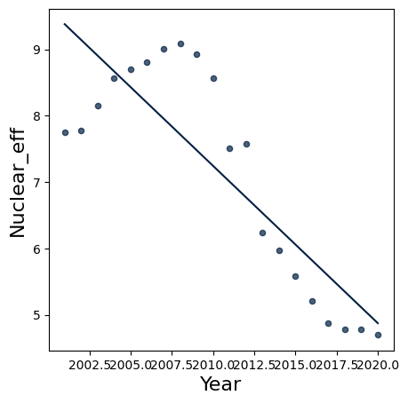

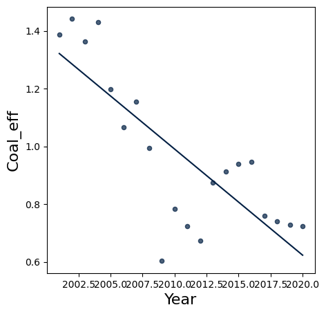

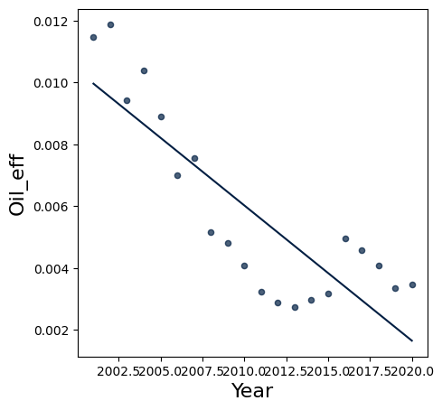

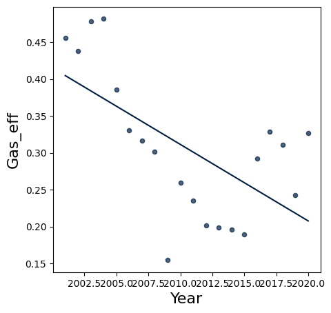

```python
Extended_Materialcost.scatter('Year', 'Nuclear_eff',fit_line="True")
Extended_Materialcost.scatter('Year', 'Coal_eff',fit_line="True")
Extended_Materialcost.scatter('Year', 'Oil_eff',fit_line="True")
Extended_Materialcost.scatter('Year', 'Gas_eff',fit_line="True")
```

# **5. 수요 가격 탄력성 (Price Demand Elasticity)**

**생산 효율도가 낮은 원료 가스와 생산 효율도가 높은 원자력의 수요 가격 탄력성 비교**

**1. 가스**

| Year | Gas_Steam Power | Cost/1kWh | Cost |
| --- | --- | --- | --- |
| 2019 | 0.012 | 113.936 | 0.105322 |
| 2018 | 0 | 88.9666 | 0 |
| 2017 | 220183 | 84.17 | 2.61593e+06 |
| 2016 | 368541 | 94.886 | 3.88404e+06 |
| 2015 | 222472 | 146.244 | 1.52124e+06 |
| 2014 | 568123 | 141.591 | 4.01243e+06 |
| 2013 | 3.52589e+06 | 139.485 | 2.52779e+07 |
| 2012 | 3.45287e+06 | 137.456 | 2.51198e+07 |
| 2011 | 2.23262e+06 | 117.551 | 1.89928e+07 |
| 2010 | 2.28754e+06 | 106.554 | 2.14684e+07 |
| 2009 | 761682 | 179.22 | 4.24999e+06 |
| 2008 | 1.51776e+06 | 91.96 | 1.65046e+07 |
| 2007 | 2.0277e+06 | 87.55 | 2.31605e+07 |
| 2006 | 1.25816e+06 | 83.86 | 1.5003e+07 |
| 2005 | 786366 | 71.77 | 1.09568e+07 |
| 2004 | 733318 | 57.462 | 1.27618e+07 |
| 2003 | 1.67418e+06 | 57.94 | 2.88951e+07 |
| 2002 | 1.77121e+06 | 63.152 | 2.80467e+07 |
| 2001 | 1.55693e+06 | 60.756 | 2.56259e+07 |

```
[200.0, -200.0, -50.399847806442409, 49.430237139398265, -87.440889359636714, -144.49229753112596, 2.092722842398107, 42.925035054183603, -2.4301357540741377, 100.08182412371937, -66.339043056533498, -28.765656624915664, 46.839910209090114, 46.151543564482829, 6.9814745610605122, -78.16115020820159,…
[200.0, -200.0, -39.018869144238074, 87.425812917034946, -90.037671986628823, -145.204767972821, 0.62749832961543583, 27.779079841416898, -12.236989153577211, 133.89958171485617, -118.09066693742376, -33.560449042102583, 42.749975974892166, 31.173517311246961, -15.220471830244442, -77.45812579554247…
```

| Year | Demand rate | Price rate | Price Demand Elasticity |
| --- | --- | --- | --- |
| 2019 | 200 | 200 | 1 |
| 2018 | -200 | -200 | 1 |
| 2017 | -50.3998 | -39.0189 | 1.29168 |
| 2016 | 49.4302 | 87.4258 | 0.565396 |
| 2015 | -87.4409 | -90.0377 | 0.971159 |
| 2014 | -144.492 | -145.205 | 0.995093 |
| 2013 | 2.09272 | 0.627498 | 3.33503 |
| 2012 | 42.925 | 27.7791 | 1.54523 |
| 2011 | -2.43014 | -12.237 | 0.198589 |
| 2010 | 100.082 | 133.9 | 0.747439 |
| 2009 | -66.339 | -118.091 | 0.561764 |
| 2008 | -28.7657 | -33.5604 | 0.85713 |
| 2007 | 46.8399 | 42.75 | 1.09567 |
| 2006 | 46.1515 | 31.1735 | 1.48047 |
| 2005 | 6.98147 | -15.2205 | -0.45869 |
| 2004 | -78.1612 | -77.4581 | 1.00908 |
| 2003 | -5.63211 | 2.97984 | -1.89007 |
| 2002 | 12.8767 | 9.02054 | 1.42749 |

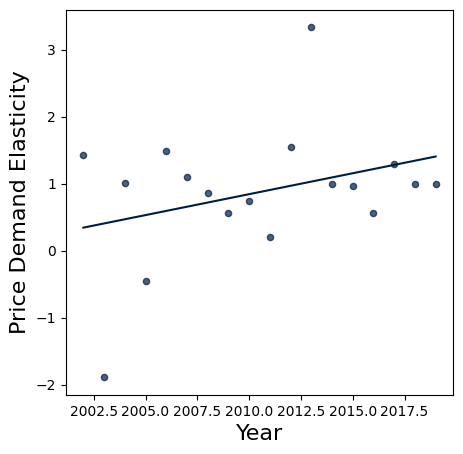

```python
Gas_Price = Powergentype.select('Year', 'Gas_Steam Power')
Gas_Price = Gas_Price.where("Year", are.above(2000))
Gas_Price = Gas_Price.with_column("Cost/1kWh", Extended_Materialcost.column("Gas")[1:])
Total_Price_G = Gas_Price.apply(lambda x, y: (x/y)*1000, "Gas_Steam Power", "Cost/1kWh")
Gas_Price = Gas_Price.with_column("Cost", Total_Price_G)
Gas_Price.show(20)
a = []
for i in range(18):
  demandrate = (Gas_Price.column("Gas_Steam Power")[i]-Gas_Price.column("Gas_Steam Power")[i+1])/((Gas_Price.column("Gas_Steam Power")[i]+Gas_Price.column("Gas_Steam Power")[i+1])/2)*100
  a.append(demandrate)
print(a)
b = []
for j in range(18):
  pricerate = (Gas_Price.column("Cost")[j]-Gas_Price.column("Cost")[j+1])/((Gas_Price.column("Cost")[j]+Gas_Price.column("Cost")[j+1])/2)*100
  b.append(pricerate)
print(b)
Elasticity_G = Gas_Price.select('Year')
Elasticity_G = Elasticity_G.where("Year", are.above(2001))
Elasticity_G = Elasticity_G.with_column("Demand rate", a)
Elasticity_G = Elasticity_G.with_column("Price rate", b)
Elasticity_G_1 = Elasticity_G.apply(lambda x, y: x/y, "Demand rate", "Price rate")
Elasticity_G = Elasticity_G.with_column("Price Demand Elasticity", Elasticity_G_1)
Elasticity_G.show(20)
Elasticity_G.scatter('Year', 'Price Demand Elasticity',fit_line="True")
```

```python
b = 0
for j in Elasticity_G.column("Price Demand Elasticity"):
  b += j
print(b/18)
```

```
0.874024917996
```

아래 표는 연도와 수요 가격 탄력성 간의 상관계수이다. 상관 계수가 0.328092로 증가하지만 매우 약한 상관관계를 보이고 있다.

```python
Corr = Elasticity_G.select('Year', 'Price Demand Elasticity')
Corr = Corr.to_df()
Corr.corr()
```

|  | Year | Price Demand Elasticity |
| --- | --- | --- |
| Year | 1.000000 | 0.328092 |
| Price Demand Elasticity | 0.328092 | 1.000000 |

**2. 원자력**

| Year | Nuclear Power | Cost/1kWh | Cost |
| --- | --- | --- | --- |
| 2019 | 1.4591e+08 | 5.862 | 2.48908e+10 |
| 2018 | 1.33505e+08 | 5.86177 | 2.27756e+10 |
| 2017 | 1.48427e+08 | 5.74 | 2.58583e+10 |
| 2016 | 1.61995e+08 | 5.38 | 3.01106e+10 |
| 2015 | 1.64762e+08 | 5.01227 | 3.28718e+10 |
| 2014 | 1.56407e+08 | 4.68882 | 3.33573e+10 |
| 2013 | 1.38784e+08 | 4.49185 | 3.08968e+10 |
| 2012 | 1.50327e+08 | 3.693 | 4.0706e+10 |
| 2011 | 1.54723e+08 | 3.726 | 4.15253e+10 |
| 2010 | 1.48596e+08 | 3.27 | 4.54421e+10 |
| 2009 | 1.47771e+08 | 3.1362 | 4.71178e+10 |
| 2008 | 1.50958e+08 | 3.08 | 4.90123e+10 |
| 2007 | 1.42937e+08 | 3.11 | 4.59605e+10 |
| 2006 | 1.48749e+08 | 3.18 | 4.67764e+10 |
| 2005 | 1.46779e+08 | 3.22 | 4.55835e+10 |
| 2004 | 1.30715e+08 | 3.268 | 3.99984e+10 |
| 2003 | 1.29672e+08 | 3.437 | 3.77282e+10 |
| 2002 | 1.19103e+08 | 3.602 | 3.30658e+10 |
| 2001 | 1.12133e+08 | 3.611 | 3.10532e+10 |

```
[8.8788444324022979, -10.585151554956946, -8.7418974649492185, -1.6938015081317221, 5.2034329601267579, 11.939773776718358, -7.9853825468163793, -2.8820244120702596, 4.0402341221833131, 0.5566787396734818, -2.1337944740955002, 5.4582549481797411, -3.9849171244788519, 1.3331157101204596, 11.578064137…
[8.8749810689251429, -12.67732425250458, -15.195215537868126, -8.7682207180128469, -1.4660342665502553, 7.658515316383431, -27.398799055343115, -1.9925443639030265, -9.0076469592833153, -3.6207350824357372, -3.9415929097448177, 6.4267102319537708, -1.7595521140293402, 2.5830081023491833, 13.05212880…
```

| Year | Demand rate | Price rate | Price Demand Elasticity |
| --- | --- | --- | --- |
| 2019 | 8.87884 | 8.87498 | 1.00044 |
| 2018 | -10.5852 | -12.6773 | 0.834967 |
| 2017 | -8.7419 | -15.1952 | 0.575306 |
| 2016 | -1.6938 | -8.76822 | 0.193175 |
| 2015 | 5.20343 | -1.46603 | -3.54933 |
| 2014 | 11.9398 | 7.65852 | 1.55902 |
| 2013 | -7.98538 | -27.3988 | 0.29145 |
| 2012 | -2.88202 | -1.99254 | 1.4464 |
| 2011 | 4.04023 | -9.00765 | -0.448534 |
| 2010 | 0.556679 | -3.62074 | -0.153747 |
| 2009 | -2.13379 | -3.94159 | 0.541353 |
| 2008 | 5.45825 | 6.42671 | 0.849308 |
| 2007 | -3.98492 | -1.75955 | 2.26473 |
| 2006 | 1.33312 | 2.58301 | 0.51611 |
| 2005 | 11.5781 | 13.0521 | 0.887063 |
| 2004 | 0.801157 | 5.84158 | 0.137147 |
| 2003 | 8.49673 | 13.1718 | 0.645071 |
| 2002 | 6.02836 | 6.27768 | 0.960286 |

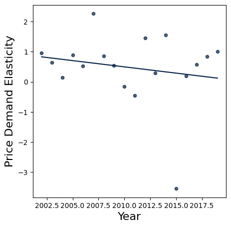

```python
Nuclear_Price = Powergentype.select('Year', 'Nuclear Power')
Nuclear_Price = Nuclear_Price.where("Year", are.above(2000))
Nuclear_Price = Nuclear_Price.with_column("Cost/1kWh", Extended_Materialcost.column("Nuclear")[1:])
Total_Price_N = Nuclear_Price.apply(lambda x, y: (x/y)*1000, "Nuclear Power", "Cost/1kWh")
Nuclear_Price = Nuclear_Price.with_column("Cost", Total_Price_N)
Nuclear_Price.show(20)
c = []
for i in range(18):
  demandrate = (Nuclear_Price.column("Nuclear Power")[i]-Nuclear_Price.column("Nuclear Power")[i+1])/((Nuclear_Price.column("Nuclear Power")[i]+Nuclear_Price.column("Nuclear Power")[i+1])/2)*100
  c.append(demandrate)
print(c)
d = []
for j in range(18):
  pricerate = (Nuclear_Price.column("Cost")[j]-Nuclear_Price.column("Cost")[j+1])/((Nuclear_Price.column("Cost")[j]+Nuclear_Price.column("Cost")[j+1])/2)*100
  d.append(pricerate)
print(d)
Elasticity_N = Gas_Price.select('Year')
Elasticity_N = Elasticity_N.where("Year", are.above(2001))
Elasticity_N = Elasticity_N.with_column("Demand rate", c)
Elasticity_N = Elasticity_N.with_column("Price rate", d)
Elasticity_N_1 = Elasticity_N.apply(lambda s, t: s/t, "Demand rate", "Price rate")
Elasticity_N = Elasticity_N.with_column("Price Demand Elasticity", Elasticity_N_1)
Elasticity_N.show(20)
Elasticity_N.scatter('Year', 'Price Demand Elasticity',fit_line="True")
```

```python
c = 0
for j in Elasticity_N.column("Price Demand Elasticity"):
  c += j
print(c/18)
```

```
0.475012344974
```

아래 표는 연도와 수요 가격 탄력성 간의 상관계수이다. 상관 계수가 -0.186923으로 감소하지만 매우 약한 상관관계를 보이고 있다.

```python
Corr = Elasticity_N.select('Year', 'Price Demand Elasticity')
Corr = Corr.to_df()
Corr.corr()
```

|  | Year | Price Demand Elasticity |
| --- | --- | --- |
| Year | 1.000000 | -0.186923 |
| Price Demand Elasticity | -0.186923 | 1.000000 |

- 2002년부터의 수요 가격 탄력성을 가스와 원자력에 한해서 평균값을 구한 결과 각각 0.8740249179960408, 0.47501234497423034으로 나타난다. 가스의 수요 가격 탄력성은 원자력의 수요 가격 탄력성에 비해 높다. 이 분석에서 수요 가격 탄력성이 높다는것은 가격이 증가함에 따라 수요의 증가율이 더욱 높았다는 것을 알 수 있다. 즉, 가스의 경우 효율적인 지출을 하지 못했다고 분석 할 수 있다.
- 수요 가격 탄력성은 소비자의 구매에 따라 결정 되는 것이다. 하지만 에너지 같은 경우 사용하는 만큼 생산해야 하는 것이다. 즉, 에너지는 반드시 필요한 지출인 것이다. 그렇다면 이때 발생하는 가격 탄력성은 소비자의 소비량 보다는 가격에 의해서 결정 된다고 판달 할 수 있다. 이에 우리는 분석을 통해서 수요가격탄력성이 낮게 나오는 원료를 이용하여 에너지 발전에 사용하는 것이 효율적이라는 것을 알 수 있다